# Carflix

Alexandre

02/11/2021

## Análise Exploratória de dados de preficicação de veículos

Partimos de cerca de 40.000 entradas, a análise inicial contem algumas tratativas para facilitar análises futuras, o script por ser conferido no arquivo ‘Script.R’

Iniciaremos observando comportamento de preços oferecidos com base no ano de fabricação e tipo de cambio.

## Preço por tipo de Cambio

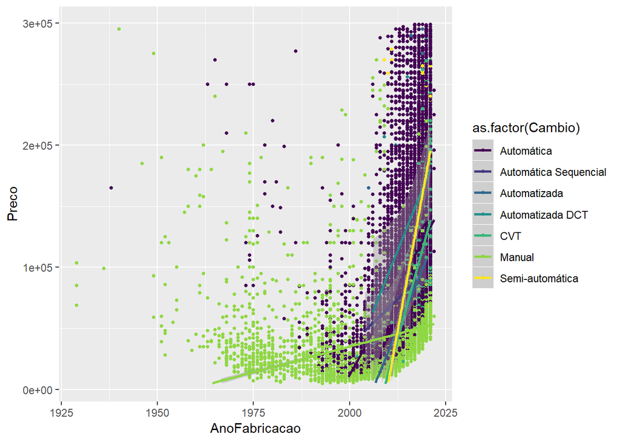

Vale notar que o percentil final (ultimos 5%) foi desconsiderado para eliminar outliers. Podemos notar que a regressão para veículos Semi-Automáticos tem um corportamento de aumento mais acentuado que os demais tipos.

### Observando dados a partir de 2010

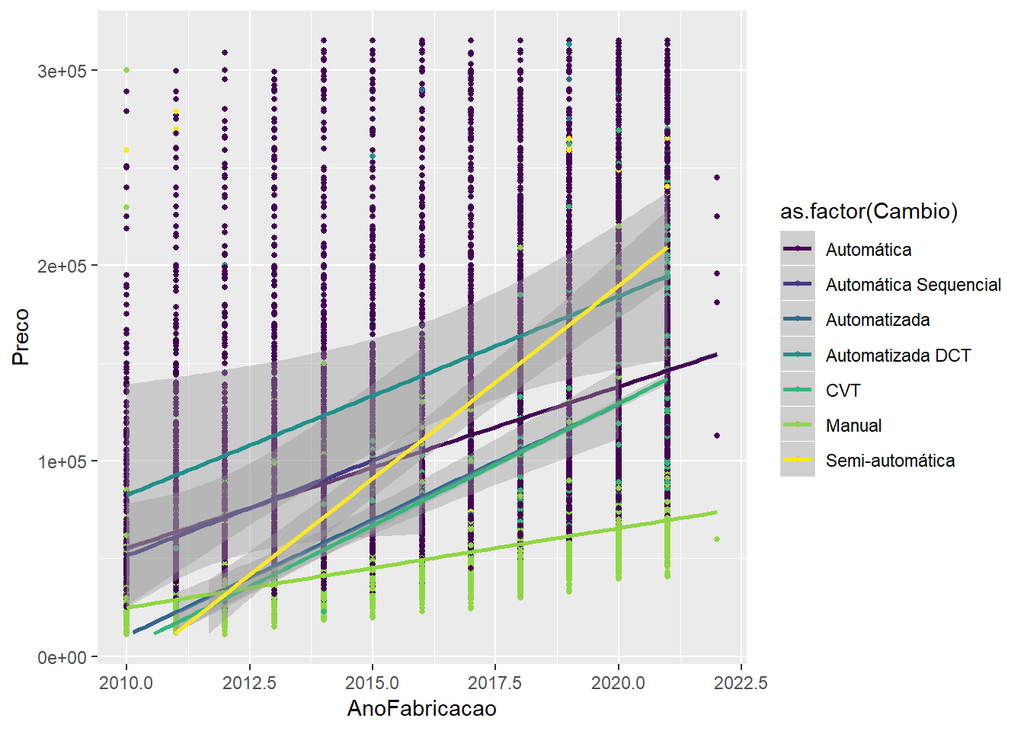

O mesmo comportamento é observado para esse tipo de veículo, nos mostrando possibilidades de extrapolação visando a precificação deste tipo de veículo nos próximos ciclos.

Comportamento similar é observado quando comparamos o Ano do Modelo do veículo, e não de fabricação.

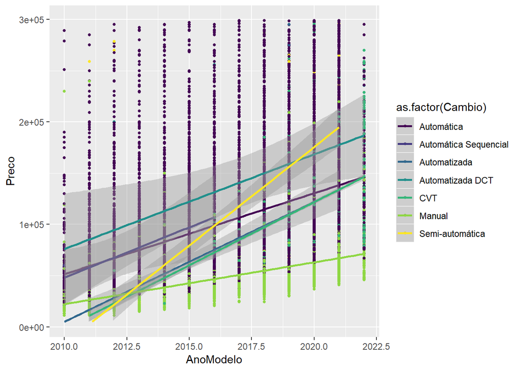

Entretanto existem outros fatores que valem ser notados:

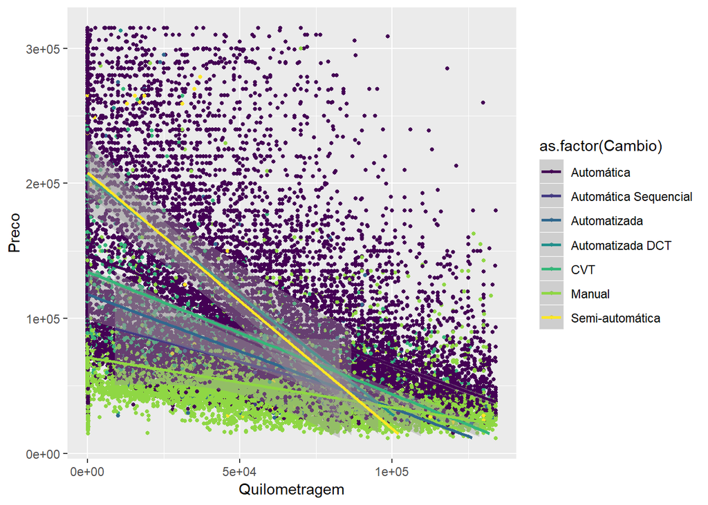

Os valores de veículos semi-automáticos diminuem mais rapidamente que outras categorias quando comparamos o preço pela Quilomtragem do veículo.

Não surpreendemente, características como Cor Primária não nos trazem incialmente insights de precificação média, nem podemos associar regressões confiáveis observando essa característica somente.

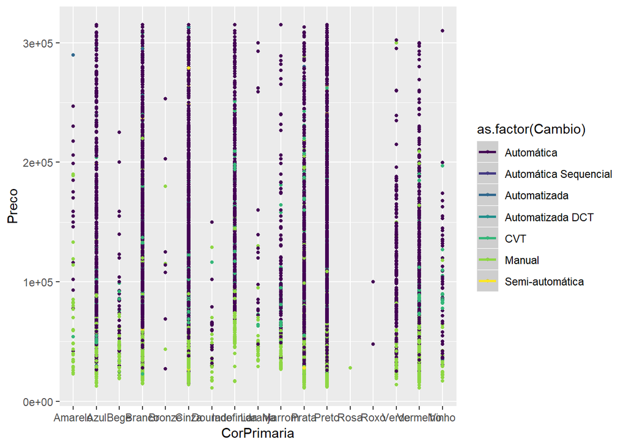

Entretanto nos ajudam a ter dimensão do volume de veículos com cores não usuais em prospecção de vendas.